# Exploratory Analysis of the Spread of the SARS-CoV-2 Omicron (B.1.1.529) Variant in Austria

Fabian Valka

20th of December 2021

# 1 Variant tracking in Austria

## 1.1 Surveillance system

Austria performs both variant specific PCR testing on positive PCR samples, as well as sequencing. Sequencing is split up into two parts with sentinel surveillance for new variants and targeted sequencing of specific variants assigned in variant specific PCR sampling.

Combined results of the variant specific PCR testing are published as weekly whole-country aggregated case counts by VOC in an online report.

It is not clearly specified whether the report includes cases by reporting or lab diagnosis date, but since later reports always include increases in VOC cases in previous weeks it is assumed that the VOC cases are grouped into weeks by original lab diagnosis date, similar to other case data published in Austria. The report is based upon the variant specified in the austrian epidemiological tracking system (EMS).

## 1.2 Variants tracked in Austria

Austria currently tracks the variants shown in table 1.1.

Table 1.1: Variants tracked in Austria. Data available refers to the number of variants detected being reported in the AGES variant surveillance report. “PCR Screening” and “Sequenced when found in PCR” as defined by the guidelines of the Austrian health ministry (Bundesministerium Soziales, Gesundheit, Pflege und Konsumentenschutz) as of the 20th of December 2021, last updated on the 1st of December 2021.

| WHO Label | Pango Lineage | PCR Screening | Sequenced when found in PCR | Data Available |
| --- | --- | --- | --- | --- |
| Alpha | B.1.1.7 | No | No | Yes |
| Beta | B.1.351 | Yes | Yes | Yes |
| Gamma | P.1 | Yes | Yes | Yes |
| Delta | B.1.617.2 | Yes | No | Yes |
| Omicron | B.1.1.529 | Yes | Yes | Yes |

| Date, Week Ending | B.1.1.7 (Alpha) | B.1.351 (Beta) | P.1 (Gamma) | B.1.617.2 (Delta) | B.1.1.529 (Omikron) | VOC Assigned Cases | All Cases | Proportion Assigned to VOC |
| --- | --- | --- | --- | --- | --- | --- | --- | --- |
| 2021-11-07 | 1 | 0 | 0 | 23260 | 0 | 23261 | 56514 | 41.2% |
| 2021-11-14 | 6 | 0 | 0 | 26645 | 0 | 26651 | 78831 | 33.8% |
| 2021-11-21 | 1 | 0 | 0 | 12379 | 0 | 12380 | 97354 | 12.7% |
| 2021-11-28 | 0 | 0 | 0 | 12165 | 6 | 12171 | 82691 | 14.7% |
| 2021-12-05 | 5 | 0 | 0 | 14766 | 35 | 14806 | 50930 | 29.1% |
| 2021-12-12 | 4 | 0 | 0 | 8915 | 56 | 8975 | 29410 | 30.5% |
| 2021-12-19 | 1 | 0 | 0 | 5369 | 322 | 5692 | 18985 | 30.0% |

# 2 Relative growth

## 2.1 Assumptions

All of the analyses in this section contain the following assumptions.

- Representative sampling for testing with variant specific PCR among all positive PCR tests.
  - This assumption might especially be violated in the early phase of the Omicron variants spread in Austria since targeted testing on people with a travel history to southern Africa has been performed. Also more targeted contact tracing efforts and preferred testing of suspected Omicron cases could violate this assumption for early Omicron case reports.
- All samples are one of the tracked variants of concern. -No numbers are provided for the total number of samples tested. It is assumed that the total number of samples tested is the sum of all variant of concern cases reported.
- Representative sampling for regions within Austria.
  - Currently weekly data about VOC cases are only available for Austria as a whole.

## 2.2 Multinomial model

### 2.2.1 Methods

A Bayesian multinomial GLMM was specified using brms (version 2.16.3). Variant of concern data starting from the 1st of September 2021 for the following variants were included: Alpha (B.1.1.7), Delta (B.1.617.2) and Omicron (B.1.1.529) At the beginning of September 3 samples of Gamma (P.1) were also reported and 1 sample of Beta (B.1.351). Detection of other variants of concern has not been reported in Austria in the time period from 2021-09-01 to 2021-12-19. Estimates of CIs are Bayesian credible intervals estimated using highest density intervals.

A simple model structure with one growth rate and intercept per variant was used. An observation-level random effect was added to account for overdispersion in the VOC case data. Delta (B.1.617.2) was used as the reference variant for the model since it was detected over the whole time period.

### 2.2.2 Results

We estimate that Omicron (B.1.1.529) has a daily growth advantage of 0.25 (90% ci 0.19 - 0.33) over Delta (B.1.617.2) in Austria.

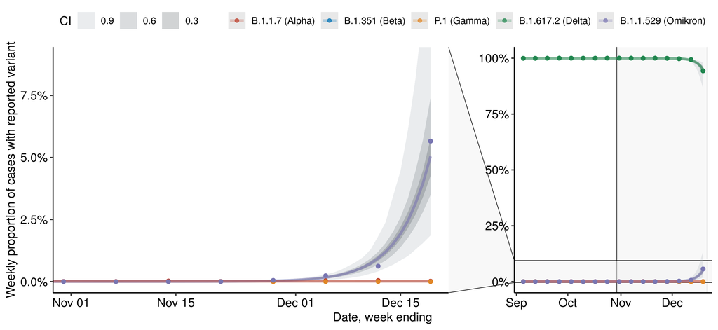

Figure 2.1: Multinomial model fit.

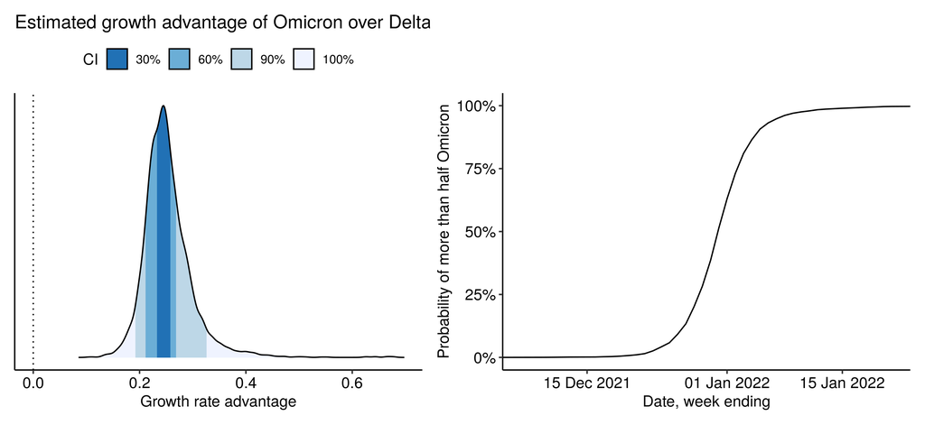

Figure 2.2: Posterior distribution of the growth advantage in the multinomial model of Omicron over Delta.